# Analisis Data Kelompok 6

# Packages

```r
library(ggplot2)
library(tsibble)
library(tseries)
library(MASS)
library(forecast)
library(TSA)
library(TTR)
library(aTSA)
library(graphics)
library(fGarch)
library(readxl)
library(rugarch)
```

# Input Data

Data yang digunakan merupakan data suhu harian berjumlah 501 periode.

```r
data <- read_excel("C:/Users/Shabrina/Storage/University/Semester 5/Metode Peramalan Deret Waktu/Projek/data suhu.xlsx", sheet = "Data Utama")
suhu <- data$Tavg
suhu.ts <- ts(suhu)
suhu.ts
```

```
## Time Series:
## Start = 1
## End = 501
## Frequency = 1
##   [1] 26.3 27.5 26.6 26.4 27.4 29.6 29.6 28.1 29.0 30.1 28.8 29.1 29.2 29.2 29.8
##  [16] 28.9 27.6 27.7 27.5 28.6 28.6 29.2 28.6 29.1 27.2 27.8 27.6 25.6 26.7 28.0
##  [31] 27.8 27.0 27.2 26.7 27.7 28.4 29.2 27.8 27.1 27.4 27.9 27.5 25.0 27.6 27.3
##  [46] 28.1 27.1 27.0 27.6 27.5 27.5 28.0 27.3 26.9 25.8 27.0 26.7 27.1 27.0 26.7
##  [61] 25.1 27.0 26.8 26.6 28.3 27.7 26.5 27.1 27.8 28.5 28.4 28.4 27.2 25.5 27.4
##  [76] 28.6 28.3 28.7 28.7 29.2 29.1 29.3 29.3 27.9 26.8 27.4 27.3 27.5 26.3 28.8
##  [91] 28.1 28.8 28.1 28.7 29.0 30.3 28.7 28.9 28.9 29.1 28.9 29.6 29.4 28.3 28.3
## [106] 28.9 29.3 29.1 29.7 28.9 29.2 29.6 29.8 29.5 28.5 28.7 29.6 29.4 28.6 29.6
## [121] 28.8 29.0 29.8 29.4 29.2 28.8 28.5 28.7 30.4 30.3 29.2 30.8 29.0 29.5 28.7
## [136] 29.7 29.6 29.2 29.6 29.4 29.6 29.1 29.3 29.4 29.4 30.1 29.5 28.7 29.9 29.6
## [151] 29.8 29.3 29.9 30.2 29.5 29.6 27.8 29.8 29.9 29.2 29.5 29.1 30.1 30.1 29.7
```

[output cut: 23 more lines]

# Eksplorasi Data

## Plot Data Penuh

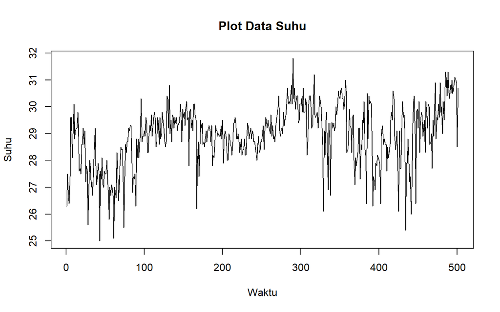

```r
plot.ts(suhu.ts, lty=1, xlab="Waktu", ylab="Suhu", main="Plot Data Suhu")
```

Berdasarkan plot data deret waktu, terlihat bahwa data cenderung memiliki trend yang naik. Berdasarkan pola data, pembagian data latih dan data uji ditetapkan dengan proporsi 86%:14%.

## Plot Data Latih

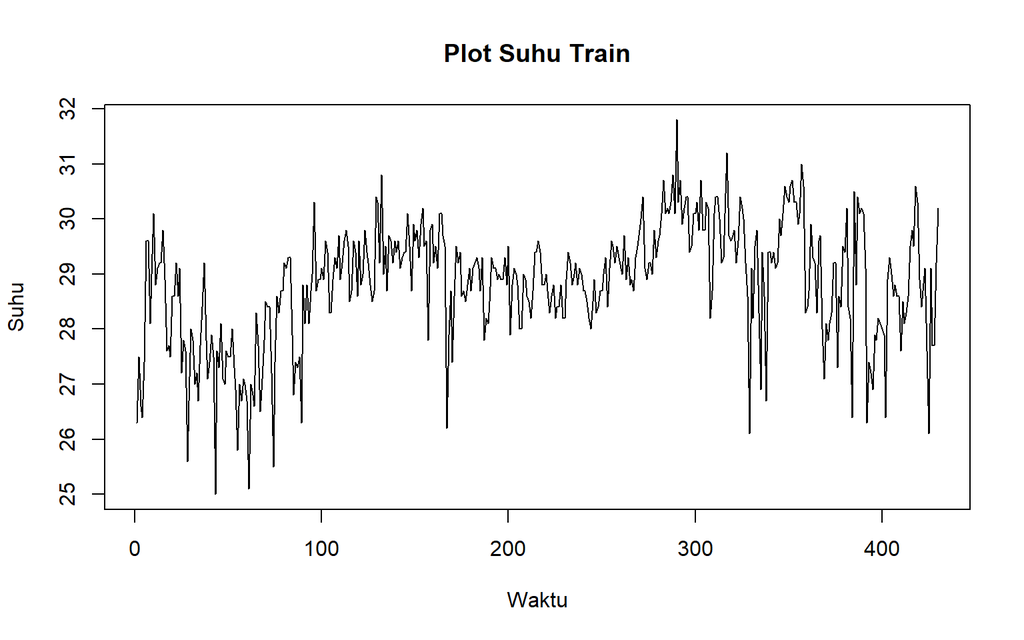

```r
suhutrain<-suhu[1:430]
train.ts<-ts(suhutrain)
plot.ts(train.ts, lty=1, xlab="Waktu", ylab="Suhu", main="Plot Suhu Train")
```

Berdasarkan plot data deret waktu pada data latih, terlihat bahwa data cenderung acak dan tidak bergerak pada nilai tengah tertentu. Hal ini mengindikasikan bahwa data tidak stasioner dalam rataan.

## Plot Data Uji

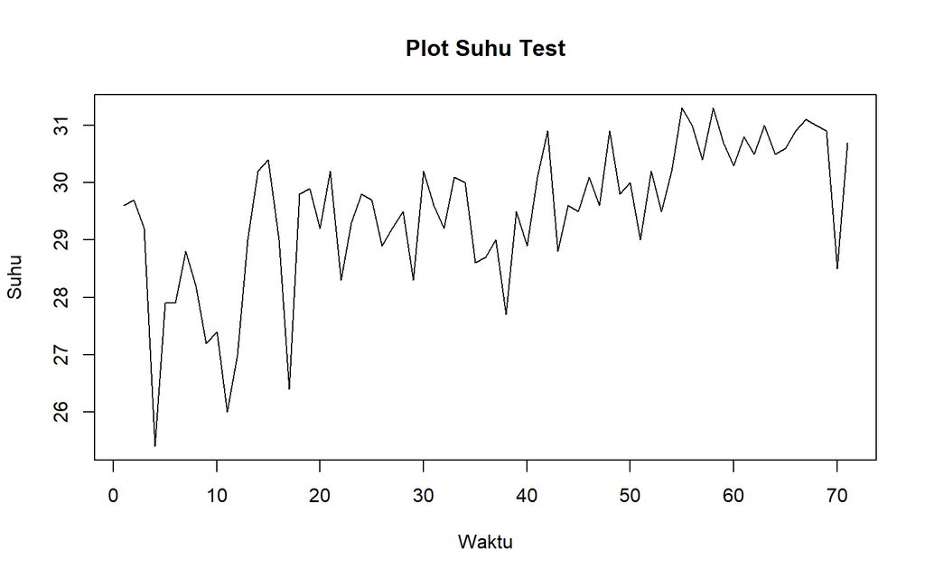

```r
suhutest<-suhu[431:501]
test.ts<-ts(suhutest)
plot.ts(test.ts, lty=1, xlab="Waktu", ylab="Suhu", main="Plot Suhu Test")
```

# Kestasioneran Data

## Plot ACF

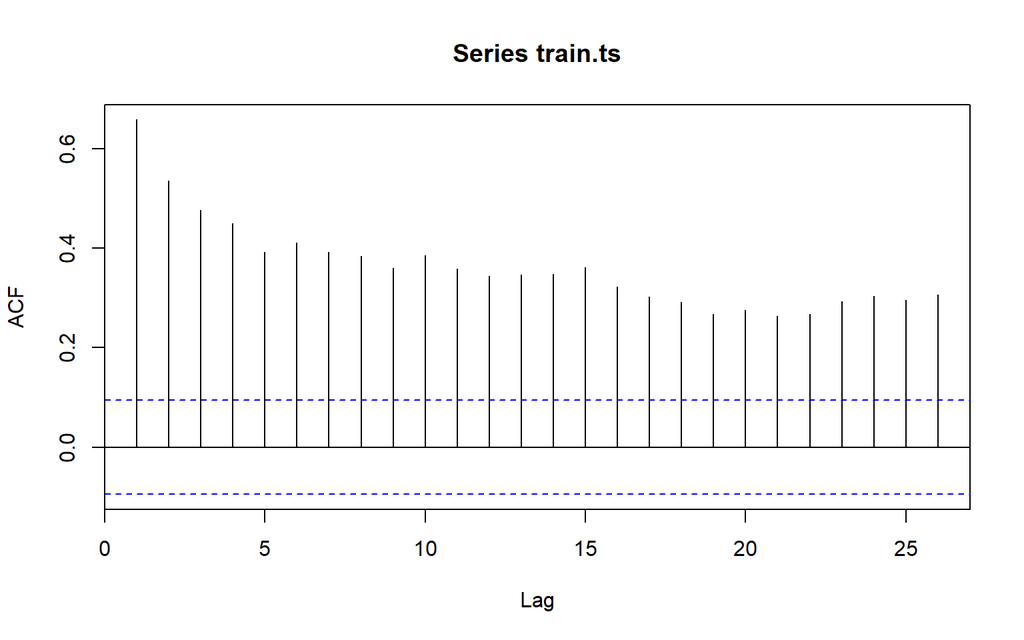

```r
acf(train.ts)
```

Berdasarkan plot ACF, terlihat bahwa plot ACF data menurun secara perlahan (*tails off slowly*). Hal ini juga menjadi indikasi bahwa data tidak stasioner dalam rataan.

## Uji ADF

```r
tseries::adf.test(train.ts)
```

```
##
##  Augmented Dickey-Fuller Test
##
## data:  train.ts
## Dickey-Fuller = -3.8183, Lag order = 7, p-value = 0.01822
## alternative hypothesis: stationary
```

$H_0$ : Data tidak stasioner dalam rataan

$H_1$ : Data stasioner dalam rataan

Berdasarkan uji ADF tersebut, didapat *p-value* sebesar 0.01822 yang lebih kecil dari taraf nyata 5% sehingga tolak $H_0$ dan menandakan bahwa data stasioner dalam rataan. Hal ini tidak sesuai dengan hasil eksplorasi menggunakan plot time series dan plot ACF. Hasil eksplorasi mengidentifikasi adanya ketidakstasioneran dalam rataan sehingga permasalahan tersebut harus ditangani.

## Plot Box-Cox

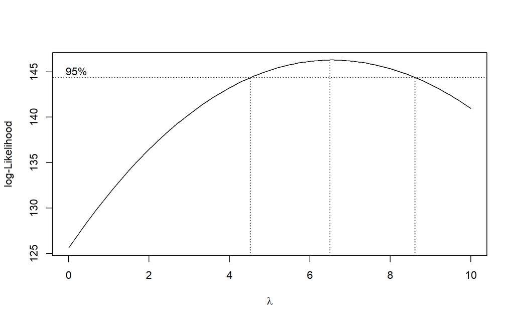

```r
index <- seq(1:430)
bc = boxcox(train.ts~index, lambda = seq(0,10,by=0.1))
```

```r
#Nilai Rounded Lambda
lambda <- bc$x[which.max(bc$y)]
lambda
```

```
## [1] 6.5
```

```r
#SK
bc$x[bc$y > max(bc$y) - 1/2 * qchisq(.95,1)]
```

```
##  [1] 4.6 4.7 4.8 4.9 5.0 5.1 5.2 5.3 5.4 5.5 5.6 5.7 5.8 5.9 6.0 6.1 6.2 6.3 6.4
## [20] 6.5 6.6 6.7 6.8 6.9 7.0 7.1 7.2 7.3 7.4 7.5 7.6 7.7 7.8 7.9 8.0 8.1 8.2 8.3
## [39] 8.4 8.5 8.6
```

```r
train.cox = train.ts^5
```

Plot Boxcox menunjukkan nilai *rounded value* ($\lambda$) optimum sebesar **6,5** dan pada selang kepercayaan 95% nilai memiliki batas bawah **4,6** dan batas atas **8,6**. Selang tersebut tidak memuat nilai satu sehingga dapat dikatakan bahwa data tidak stasioner dalam ragam.

# Penanganan Ketidakstasioneran Data

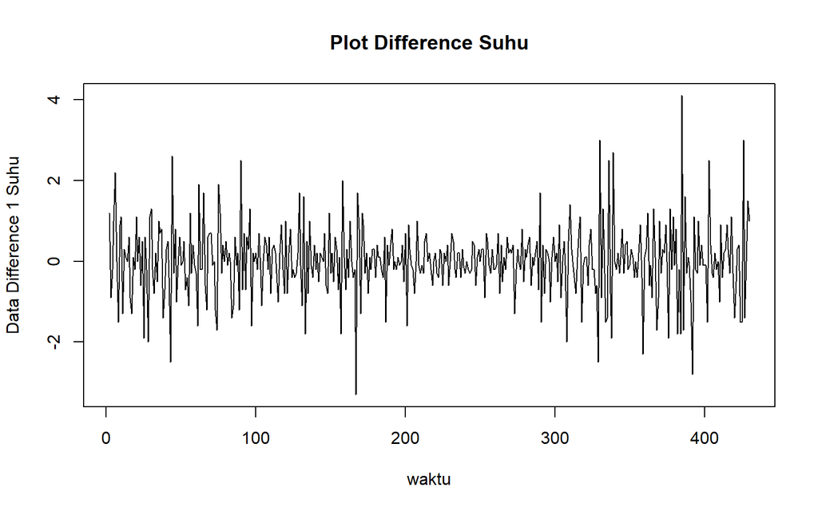

```r
train.diff<-diff(train.ts,differences = 1)
plot.ts(train.diff, lty=1, xlab="waktu", ylab="Data Difference 1 Suhu", main="Plot Difference Suhu")
```

Berdasarkan plot data deret waktu, terlihat bahwa data sudah stasioner dalam rataan ditandai dengan data bergerak pada nilai tengah tertentu (tidak terdapat trend ataupun musiman pada data).

## Plot ACF

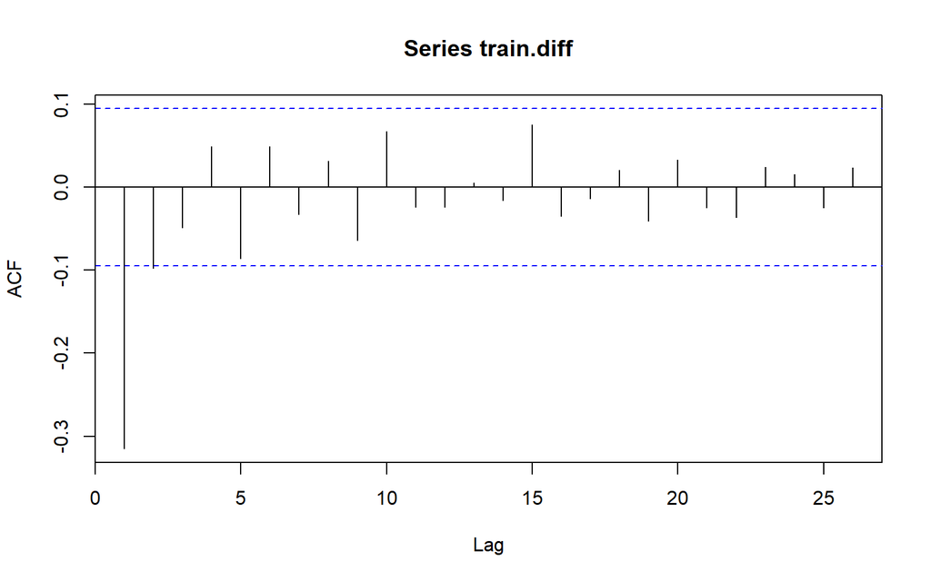

```r
acf(train.diff)
```

Berdasarkan plot tersebut, terlihat bahwa plot ACF cuts off pada lag ke 1. Hal ini menandakan data sudah stasioner dalam rataan dan ketidakstasioneran data telah berhasil tertangani.

## Uji ADF

$H_0$ : Data tidak stasioner dalam rataan

$H_1$ : Data stasioner dalam rataan

```r
tseries::adf.test(train.diff)
```

```
##
##  Augmented Dickey-Fuller Test
##
## data:  train.diff
## Dickey-Fuller = -10.555, Lag order = 7, p-value = 0.01
## alternative hypothesis: stationary
```

Berdasarkan uji ADF tersebut, didapat *p-value* sebesar 0.01 yang lebih kecil dari taraf nyata 5% sehingga tolak $H_0$ atau data stasioner dalam rataan. Hal ini sesuai dengan hasil eksplorasi menggunakan plot time series dan plot ACF sehingga ketidakstasioneran data telah berhasil ditangani dan dapat dilanjutkan ke pemodelan.

# Identifikasi Model

## Plot ACF

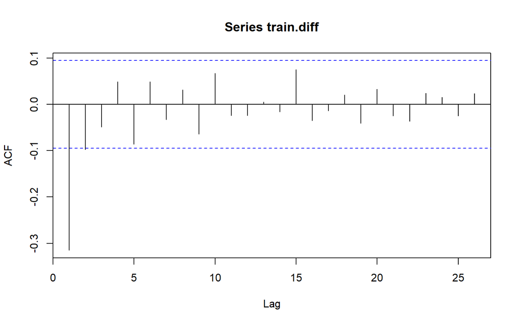

```r
acf(train.diff)
```

Berdasarkan plot tersebut, terlihat bahwa plot ACF cenderung *cuts off* pada lag ke 2, sehingga jika plot PACF dianggap *tails off*, maka model tentatifnya adalah ARIMA(0,1,2).

## Plot PACF

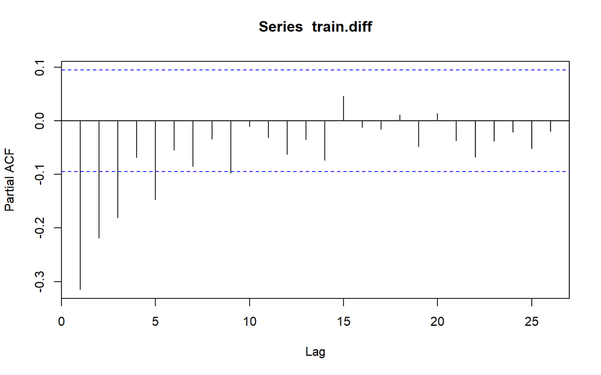

```r
pacf(train.diff)
```

Berdasarkan plot tersebut, terlihat bahwa plot PACF cenderung *cuts off* pada lag ke 3, sehingga jika plot ACF dianggap *tails off*, maka model tentatifnya adalah ARIMA(3,1,0).

## Plot EACF

```r
eacf(train.diff)
```

```
## AR/MA
##   0 1 2 3 4 5 6 7 8 9 10 11 12 13
## 0 x x o o o o o o o o o  o  o  o
## 1 x o x o o o o o o o o  o  o  o
## 2 x x o o o o o o o o o  o  o  o
## 3 x x x x x o o o o o o  o  o  o
## 4 x x x x o o o o o o o  o  o  o
## 5 x x o x x o o o o o o  o  o  o
## 6 x x o x x o o o o o o  o  o  o
## 7 x x o x o x o o o o o  o  o  o
```

Identifikasi model menggunakan plot EACF dilakukan dengan melihat ujung segitiga pada pola segitiga nol. Dalam hal ini model tentatif yang terbentuk adalah ARIMA(0,1,2), ARIMA(0,1,3), ARIMA(1,1,3), dan ARIMA(2,1,4).